# Brazil’s Government IT spending by Vitor Bellini

This report explores a dataset containing information about Brazil’s IT contracts between 2011 and 2016 for 104,451 contracts.

# The Dataset

The dataset used to this project was generated by [SIGA](https://www12.senado.leg.br/orcamento/sigabrasil), a Brazil’s Senate public spending system. The system integrates data from several federal systems like SIAFI (Finances), SIOP (Planning and Budget), SELOR (elaboration of budget law), SIEST (Public companies), SICONV (agreements and transfer of funds), among others.

The dataset contains information about IT Federal Government contracts between the years 2011 and 2016, with data like deparment, management unit, supplier, amounts reserved, charged and payed, date, budget identification code.

The detail about the variables of the dataset is presented on the session “Univariate Analysis”.

# Univariate Plots Section

```
## [1] 104451     15
```

```
## Classes 'tbl_df', 'tbl' and 'data.frame':    104451 obs. of  15 variables:
##  $ esfera              : chr  "ORCAMENTO FISCAL" "ORCAMENTO FISCAL" "ORCAMENTO FISCAL" "ORCAMENTO FISCAL" ...
##  $ orgao.superior      : chr  "MINISTERIO DA DEFESA" "MINISTERIO DA EDUCACAO" "MINISTERIO DA JUSTICA" "PRESIDENCIA DA REPUBLICA" ...
##  $ unidade.gestora     : chr  "DIRETORIA DE ABASTECIMENTO DA MARINHA" "INST.FED.DE EDUC.,CIENC.E TEC.DO SUL DE MG" "DEPTO.DE POLICIA RODOVIARIA FEDERAL" "AGENCIA BRASILEIRA DE INTELIGENCIA" ...
##  $ gnd                 : chr  "OUTRAS DESPESAS CORRENTES" "OUTRAS DESPESAS CORRENTES" "OUTRAS DESPESAS CORRENTES" "OUTRAS DESPESAS CORRENTES" ...
##  $ data.empenho        : Date, format: "2013-11-28" "2013-10-15" ...
##  $ subelemento.despesa : chr  "SERVIÇOS DE PROCESSAMENTO DE DADOS" "COMUNICAÇÃO DE DADOS" "MANUT E CONSERV EQUIP PROCESS DADOS" "COMUNICAÇÃO DE DADOS" ...
##  $ favorecido          : chr  "CA PROGRAMAS DE COMPUTADOR, PARTICIPACOES E SERVICOS LT" "TELEFONICA BRASIL S.A." "INTERATIVA SERVICOS E EQUIPAMENTOS DE INFORMATICA LTDA" "TELEMAR NORTE LESTE S/A" ...
##  $ orgao.superior.sigla: chr  "MD" "MEC" "MJ" "PR" ...
##  $ mes                 : Ord.factor w/ 12 levels "jan"<"fev"<"mar"<..: 11 10 2 10 11 12 10 11 9 12 ...
##  $ ano                 : num  2013 2013 2015 2014 2015 ...
##  $ vlr.empenhado       : num  246408 14137 15000 15247 52978 ...
##  $ vlr.liquidado       : num  0 37 82 146 179 184 198 208 230 236 ...
##  $ vlr.pago            : num  0 37 82 146 179 184 0 208 230 236 ...
##  $ emp_pgo.index       : num  0 0 0.01 0.01 0 0 0 0.01 0.03 0.02 ...
##  $ liq_pgo.index       : num  0 1 1 1 1 1 0 1 1 1 ...
```

```
##  vlr.empenhado       vlr.liquidado          vlr.pago
##  Min.   :     8000   Min.   :        0   Min.   :        0
##  1st Qu.:    13900   1st Qu.:     7696   1st Qu.:        0
##  Median :    29087   Median :    16587   Median :    10042
##  Mean   :   368454   Mean   :   281977   Mean   :   235245
##  3rd Qu.:    91224   3rd Qu.:    53500   3rd Qu.:    33650
##  Max.   :605561275   Max.   :605561275   Max.   :605561275
```

There are 104,451 IT contracts with reserve above 8,000, between the years 2011 and 2016 on this dataset. The values below 8,000 were sliced to avoid biases. In Brazil, public bidding starts at R$ 8,000.

The dataset contains 15 variables.

By the summary table, it’s shown that there were contracts not payed. Let’s see how many contracts weren’t payed:

```
##
## FALSE  TRUE
## 61309 43142
```

```
##
## FALSE  TRUE
##  0.59  0.41
```

There were 43,142 (or 41%) contracts that didn’t have any payment.

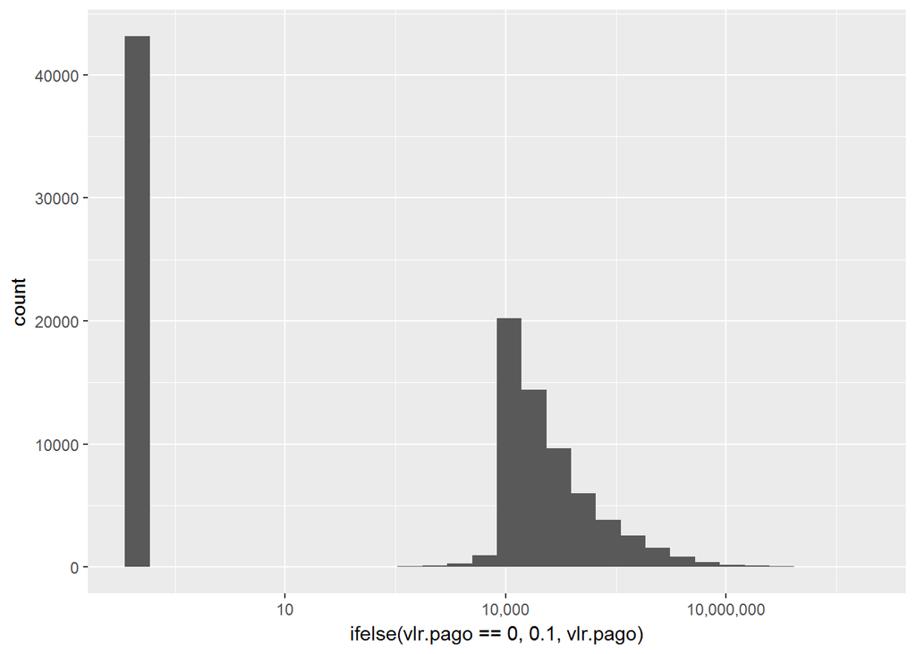

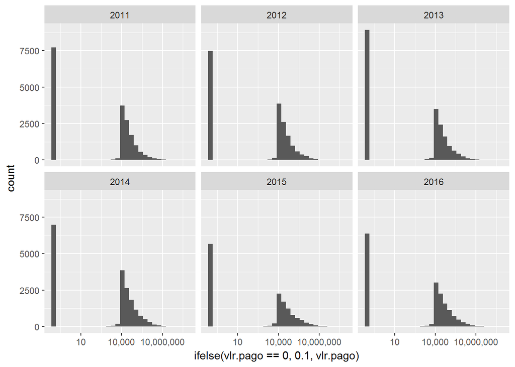

Because of the high number of contracts without payment, I’ve adjusted this histogram plot to show, on a log10 scale, these values by setting the zero values to 0.1.

Here’s some observations of the histogram of the values payed across the years:

1. There’s a high number of contracts without payment
2. The most frequent occurrence contract IT value is around 10,000
3. There is huge difference between contracts values. Since IT spending could be from simple desktop to whole datacenters, it’s expected that big range of values. That’s why the histogram is plotted on a log10 scale.

All the plots shows a skewed distribution on a log10 scale.

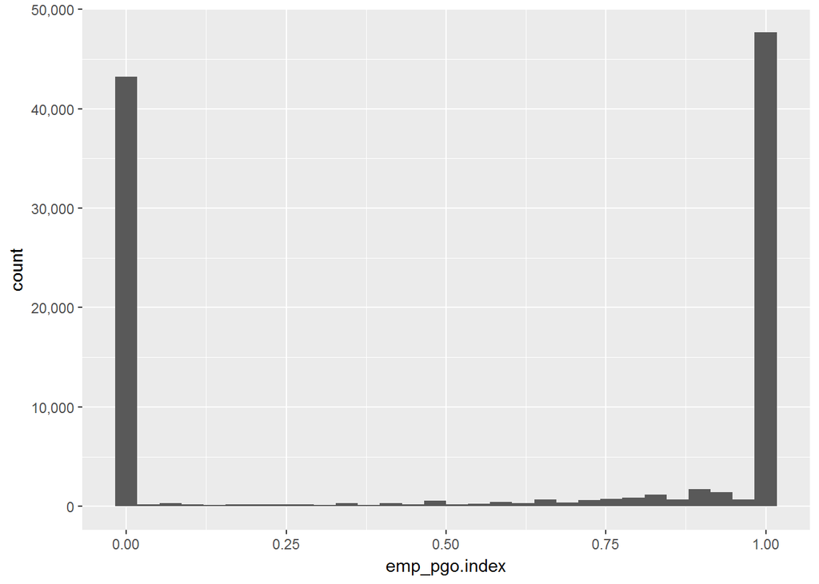

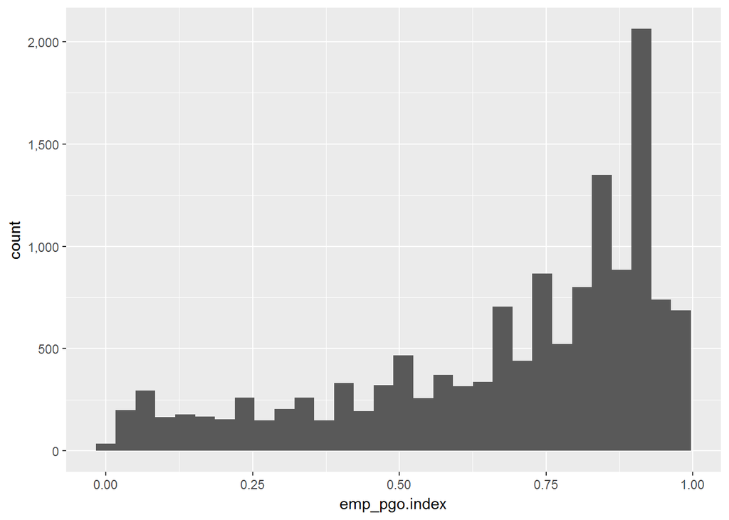

```
## # A tibble: 5 x 4
##   emp_pgo.index     n  total percentual
##           <dbl> <int>  <int>      <dbl>
## 1          1.00 47413 104451      45.39
## 2          0.00 43171 104451      41.33
## 3          0.92   981 104451       0.94
## 4          0.83   653 104451       0.63
## 5          0.91   652 104451       0.62
```

These plots shows the index of reserved vs. payed values. Between 2011 and 2016, only 45% of the IT contracts were fully payed. On the other hand, 41% weren’t payed at all.

When filtered the 0 and 1 indexes, we can see that the distribution is negatively skewed, meaning that there are more contracts payments near the planned/saved ammount.

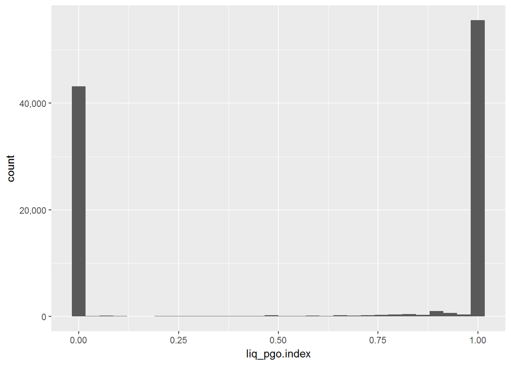

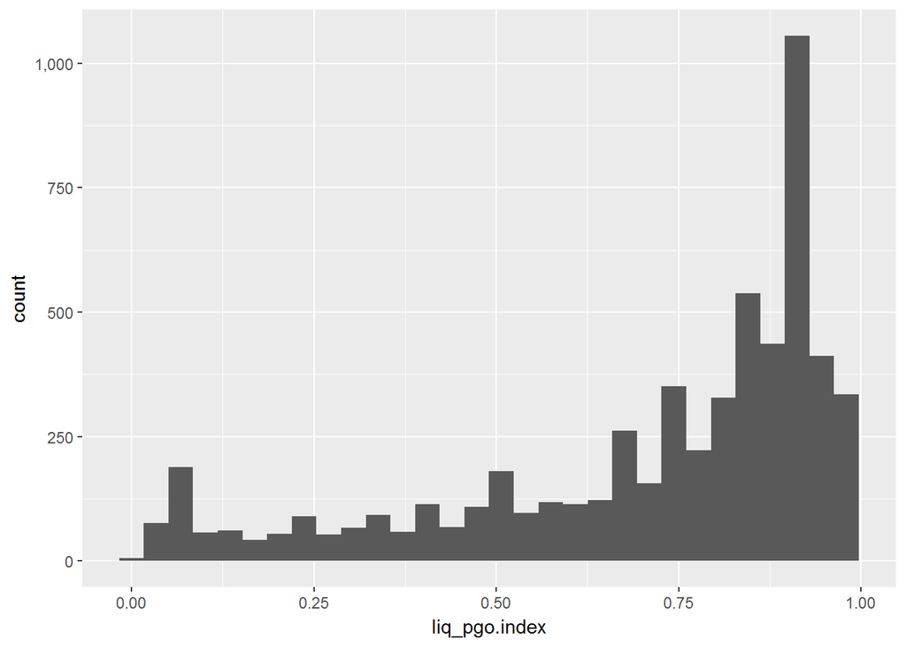

```
## # A tibble: 5 x 4
##   liq_pgo.index     n  total percentual
##           <dbl> <int>  <int>      <dbl>
## 1          1.00 55437 104451      53.07
## 2          0.00 43155 104451      41.32
## 3          0.91   410 104451       0.39
## 4          0.92   394 104451       0.38
## 5          0.90   251 104451       0.24
```

The liq_pgo.index shows the index of amount charged by the provider vs. the amount payed by the Government. This difference could be due to incomplete services, penalties, and others. Only 53.1% of the amount charged was fully payed, and 41.3% of the amount charged weren’t payed at all. In between are the contracts that had some disconuts on it’s payment.

When filtered the 0 and 1 indexes, we can see that the distribution is negatively skewed, meaning that there are more contracts payments near the charged ammount.

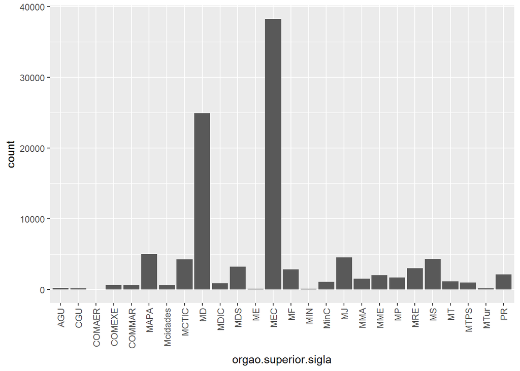

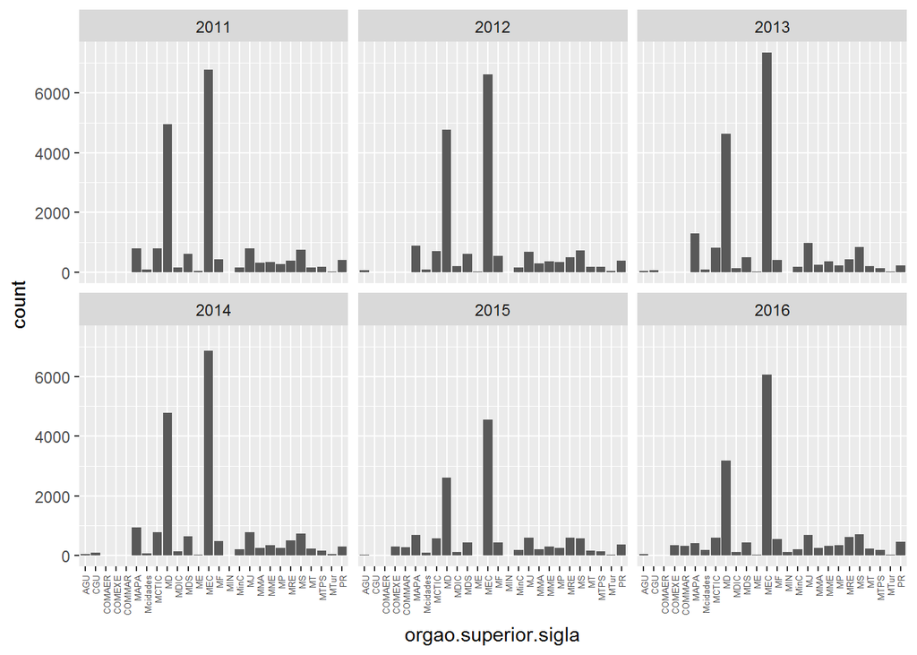

It seems that the number of IT contracts by Departments by year followed a pattern between the years. The Ministry of Education - MEC and Ministry of Defense - MD are the outliers on IT contracts numbers. On the other Departments it’s possible to see some minor changes across the years as well.

The high number of MEC and MD contracts is unusual, since each contract should represent a product or service. It does not seems necessary nor efficient to have this number of contracts. One hypothesis to the high count is that the Departments can have management units underneath it. For example, all the Federal Universities in Brazil are considered management units under MEC, and all the military units are beneath MD. Also, each management unit can have and manage its own IT contracts.

Let’s plot a table with management units count by Department to check it out.

```
## # A tibble: 46 x 2
##                                  orgao.superior total_ug
##                                           <chr>    <int>
##  1                       MINISTERIO DA EDUCACAO      896
##  2                         MINISTERIO DA DEFESA      758
##  3             MINISTERIO DA PREVIDENCIA SOCIAL      198
##  4                          COMANDO DO EXERCITO      153
##  5 MINIST. DA AGRICUL.,PECUARIA E ABASTECIMENTO      141
##  6                        MINISTERIO DA FAZENDA      141
##  7                        MINISTERIO DA JUSTICA      137
##  8                          MINISTERIO DA SAUDE      122
##  9           MINISTERIO DAS RELACOES EXTERIORES      105
## 10  MINISTERIO DO DESENVOLVIM. SOCIAL E AGRARIO      100
## # ... with 36 more rows
```

So it’s confirmed that the MEC and MD has a high number of management units beneath it and this could explain the high number of contracts on these Departments.

On the next session I will check the correlation of number of management units and number of contracts to confirm that hypothesis

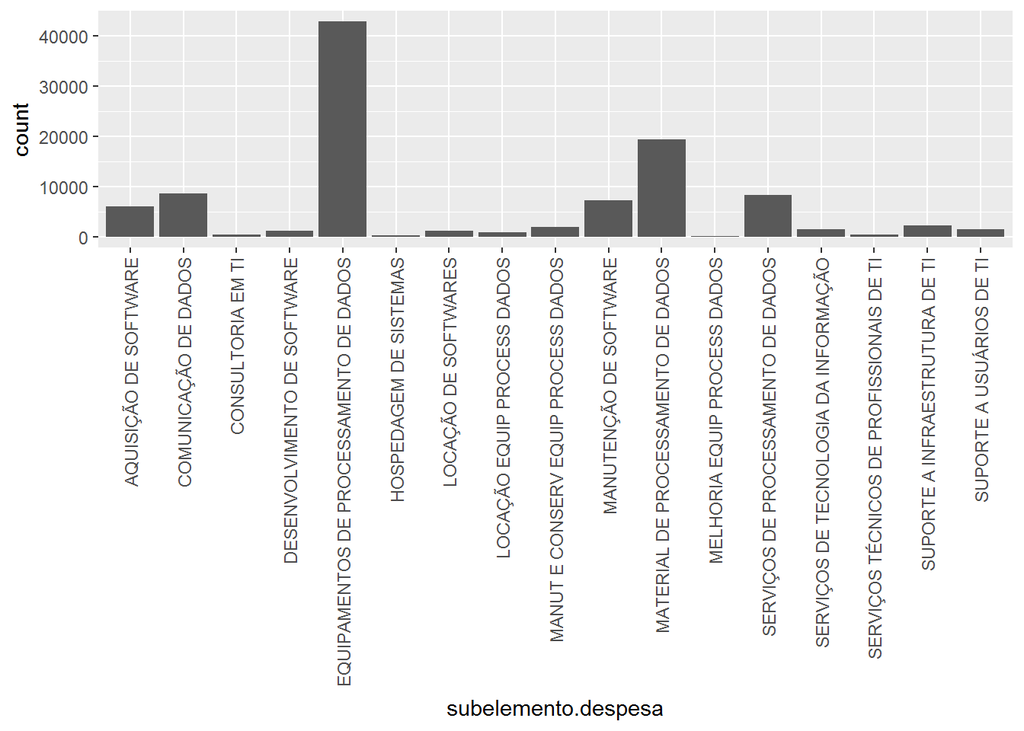

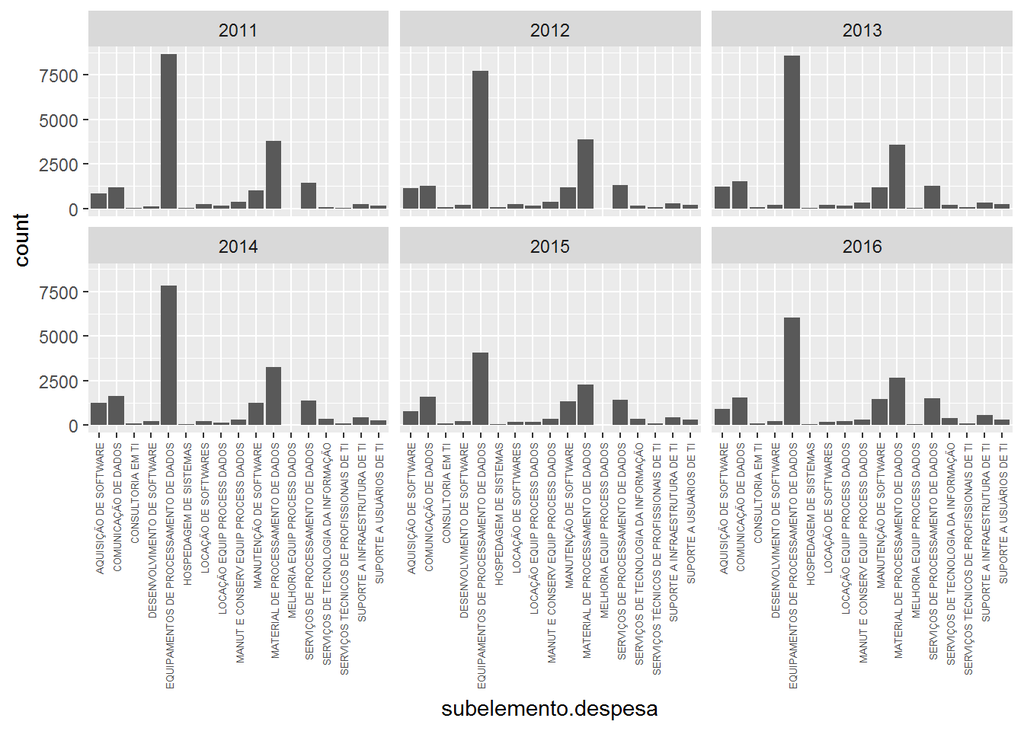

```
##
##   EQUIPAMENTOS DE PROCESSAMENTO DE DADOS
##                                    42819
##       MATERIAL DE PROCESSAMENTO DE DADOS
##                                    19447
##                     COMUNICAÇÃO DE DADOS
##                                     8705
##       SERVIÇOS DE PROCESSAMENTO DE DADOS
##                                     8286
##                   MANUTENÇÃO DE SOFTWARE
##                                     7323
##                    AQUISIÇÃO DE SOFTWARE
##                                     6119
##           SUPORTE A INFRAESTRUTURA DE TI
##                                     2281
##      MANUT E CONSERV EQUIP PROCESS DADOS
##                                     2041
##     SERVIÇOS DE TECNOLOGIA DA INFORMAÇÃO
##                                     1507
##                 SUPORTE A USUÁRIOS DE TI
##                                     1442
##                     LOCAÇÃO DE SOFTWARES
##                                     1203
##              DESENVOLVIMENTO DE SOFTWARE
##                                     1166
##              LOCAÇÃO EQUIP PROCESS DADOS
##                                      928
## SERVIÇOS TÉCNICOS DE PROFISSIONAIS DE TI
##                                      444
##                        CONSULTORIA EM TI
##                                      406
##                   HOSPEDAGEM DE SISTEMAS
##                                      244
##             MELHORIA EQUIP PROCESS DADOS
##                                       90
```

The most contracted items are “data processing equipments” and “data processing materials”.

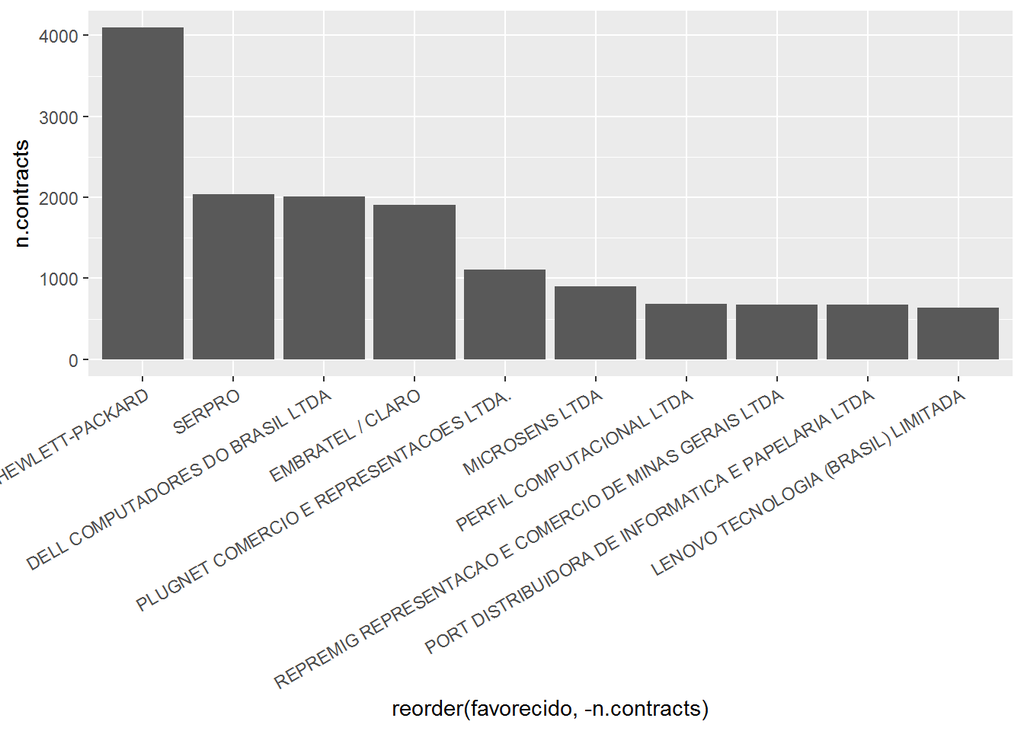

```
## # A tibble: 10 x 2
##                                                favorecido n.contracts
##                                                     <chr>       <int>
##  1                                        HEWLETT-PACKARD        4099
##  2                                                 SERPRO        2041
##  3                       DELL COMPUTADORES DO BRASIL LTDA        2010
##  4                                       EMBRATEL / CLARO        1911
##  5                PLUGNET COMERCIO E REPRESENTACOES LTDA.        1104
##  6                                         MICROSENS LTDA         899
##  7                              PERFIL COMPUTACIONAL LTDA         686
##  8 REPREMIG REPRESENTACAO E COMERCIO DE MINAS GERAIS LTDA         676
##  9     PORT DISTRIBUIDORA DE INFORMATICA E PAPELARIA LTDA         671
## 10                    LENOVO TECNOLOGIA (BRASIL) LIMITADA         634
```

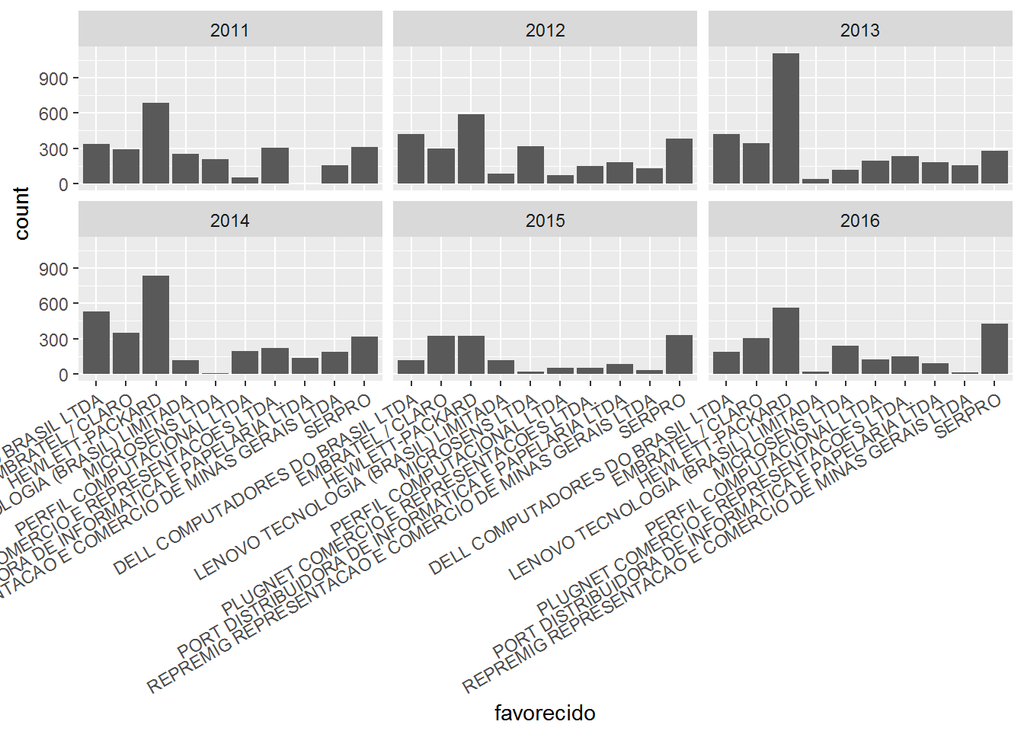

Hewlett-Packard had twice more IT contracts than the second place, Serpro between the years 2011 and 2016. The 2nd to 4th place had nearly the same count.

When plotted by year, it’s unusual the number of contracts by Hewlett-Packard on 2013.

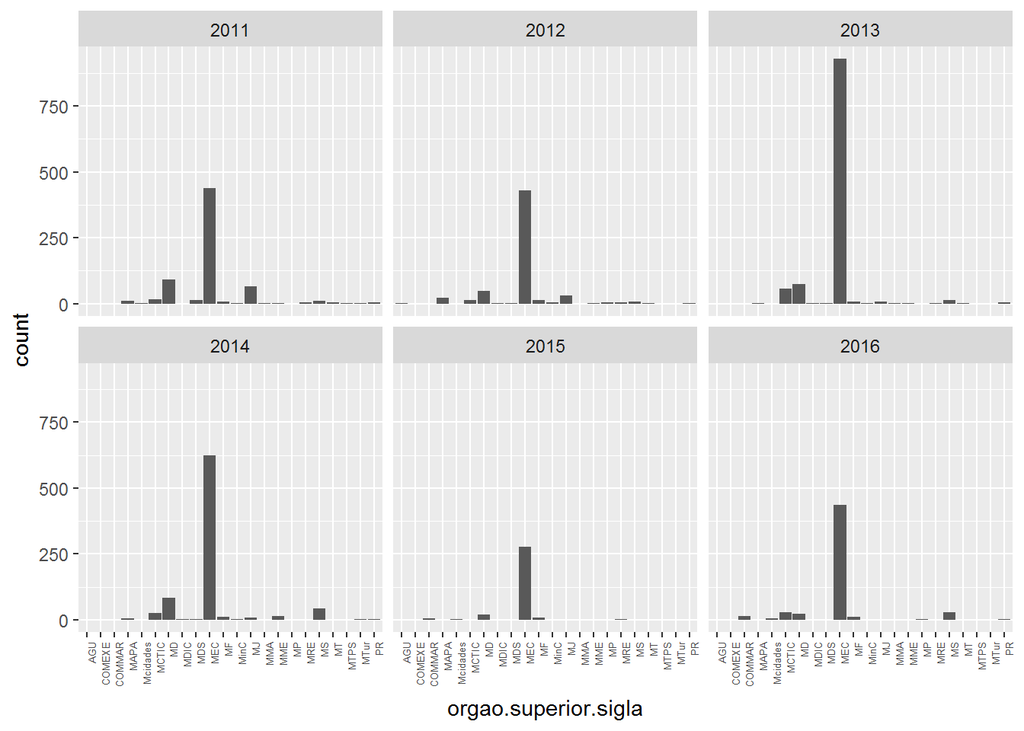

Investigating a little more, MEC is the Department with higher Hewlett-Packard number of contracts.

Let’s see the number of MEC contracts with Hewlett-Packard on 2013 by Management Unit:

```
## # A tibble: 6 x 2
##                                unidade.gestora total_contrato
##                                          <chr>          <int>
## 1  UNIVERSIDADE FEDERAL DO RIO GRANDE DO NORTE            121
## 2                UNIVERSIDADE FEDERAL DE GOIAS             81
## 3 FUNDACAO UNIVERSIDADE FEDERAL DE MATO GROSSO             76
## 4      FUNDACAO UNIVERSIDADE DE BRASILIA - FUB             63
## 5    UNIVERSIDADE FEDERAL DO RIO GRANDE DO SUL             54
## 6                 UNIVERSIDADE FEDERAL DO PARA             48
```

So 2013 MEC Hewlett-Packard higher contracts count were with Federal Universities, with “Universidade Federal do Rio Grande do Norte” on top. This University has 5 unities on 5 different cities. (font: [ufrn](http://www.ufrn.br/institucional/campi))

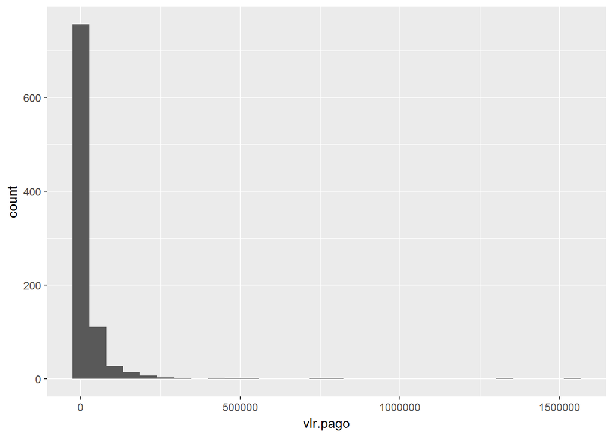

Plotting the values paid to Hewlett-Packard on 2013 by MEC we can see that a lot of contracts weren’t payed (with value 0).

```
##
## FALSE  TRUE
##   361   567
```

```
##    Min. 1st Qu.  Median    Mean 3rd Qu.    Max.
##    2509   14510   25500   60575   52615 1540080
```

Of 928 total, 567 weren’t payed vs. 361 that were, at least partial. The median is 25,500 and 75% of the distribution is below 52,615. This low values contracts suggest the purchase of simple products, like a desktop or printer material.

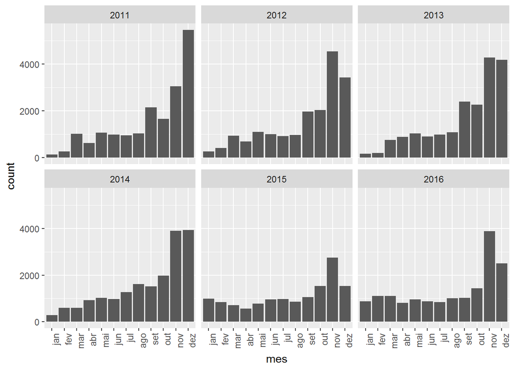

The number of contracts by month increases towards the end of the year. It’s expected because the federal budged is usually released on February and if an Department does not spend its year budget, on the next year the budget is reduced. So it is usual to budgets that have not been spent over the year to be spent on November and December.

# Univariate Analysis

### What is the structure of your dataset?

There are 104,451 IT contracts in the dataset with 15 variables:

- esfera: budgets origin
- orgao.superior: higher government administration, like a Department
- orgao.superior.sigla: higher government administration initials
- unidade.gestora: unit under the higher government administration
- gnd: type of budget, if investing or current expenditure
- data.empenho: the day that the money was separated to pay the contract
- subelemento.despesa: type of the item contracted
- favorecido: company that signed the contract
- mes: month of the contract
- ano: year of the contract
- vlr.empenhado: amount of money reserved to pay the contract
- vlr.liquidado: price of the product/service the company delivered
- vlr.pago: value payed to the company
- emp_pgo.index: index of the value reserved for the contract vs. the value payed
- liq_pgo.index: index of the amount charged vs. the value payed

### What is/are the main feature(s) of interest in your dataset?

The main features in the dataset are the values (reserved, charged and payed), the parts involved and the type of the item contracted. I’d like to see what Deparments most spent with IT, wich kind of items they bought and from who.

### What other features in the dataset do you think will help support your investigation into your feature(s) of interest?

Another interesting feature is that the dataset contains a timeseries from 2011 to 2016, making possible to compare the series over time.

### Did you create any new variables from existing variables in the dataset?

Yes. I created the variables emp_pgo.index and liq_pgo.index. The objective is to compare, of the value reserved for the contract and of the value charged, how much was actually payed. The formula used for de index was:

$$i = 1 - (reserved - payed) / reserved$$
$$i = 1 - (charged - payed) / charged$$

### Of the features you investigated, were there any unusual distributions? Did you perform any operations on the data to tidy, adjust, or change the form of the data? If so, why did you do this?

I had performed serveral ajusts on the original dataset to better understand the data and avoid incorrect conclusions. Here’s the detail:

- There were registries of year 2017, but I choosed to discard due to partial year information.
- Of 19 variables of the original dataset, I’ve selected 13 that seems more relevant for the analysis.
- The variable date was on format string and I transformed to date.
- The variables were named with case and spaces, so I renamed to lowercase without spaces, using dot when necessary.
- There were contracts with values below 8,000. In Brazil, public bidding starts at 8,000 so I tought it was better to discard these values.
- The month variable was string without ordering. I’ve applied the factor function to order the months.
- The contracts values has a huge range that if plotted on a continuous scale would show a long tail. In these cases, I performed a log10 transformation to better understand the distribution.
- There were a lot of Zero value to the variables amount reserved, charged and payed. On the histogram of the amount payed, with the log10 scale, I’ve adjusted these values to 0.1 to show them on the graph as well.
- Used the gather function of tidyr library to collapse vlr.empenhado, vlr.liquidado and vlr.pago in one categorical variable and use it on a line plot colored by value type.

# Bivariate Plots Section

```
## # A tibble: 6 x 6
##     ano total_vlr.empenhado total_vlr.liquidado total_vlr.pago
##   <dbl>               <dbl>               <dbl>          <dbl>
## 1  2011          5235286307          5235286307     3485670759
## 2  2012          5999262819          5999262819     3648498887
## 3  2013          6761310984          4127475364     3991966681
## 4  2014          6900065178          4524665820     4371280489
## 5  2015          6233355970          4476753132     4029545937
## 6  2016          7356094654          5089332678     5044607312
## # ... with 2 more variables: diff.emp_pgo <dbl>, perc.emp_pgo <dbl>
```

```
##       ano       total_vlr.empenhado total_vlr.liquidado
##  Min.   :2011   Min.   :5.235e+09   Min.   :4.127e+09
##  1st Qu.:2012   1st Qu.:6.058e+09   1st Qu.:4.489e+09
##  Median :2014   Median :6.497e+09   Median :4.807e+09
##  Mean   :2014   Mean   :6.414e+09   Mean   :4.909e+09
##  3rd Qu.:2015   3rd Qu.:6.865e+09   3rd Qu.:5.199e+09
##  Max.   :2016   Max.   :7.356e+09   Max.   :5.999e+09
##  total_vlr.pago       diff.emp_pgo        perc.emp_pgo
##  Min.   :3.486e+09   Min.   :1.750e+09   Min.   :0.3142
##  1st Qu.:3.734e+09   1st Qu.:2.231e+09   1st Qu.:0.3390
##  Median :4.011e+09   Median :2.331e+09   Median :0.3600
##  Mean   :4.095e+09   Mean   :2.319e+09   Mean   :0.3616
##  3rd Qu.:4.286e+09   3rd Qu.:2.484e+09   3rd Qu.:0.3855
##  Max.   :5.045e+09   Max.   :2.769e+09   Max.   :0.4096
```

The mean IT expense of Federal Government is 4.095 Billions of Reais by year, while the mean budget is 6.414 Billions. This means that between 2011 and 2016, 36% of the IT budget wasn’t spent. This could indicate bad planning.

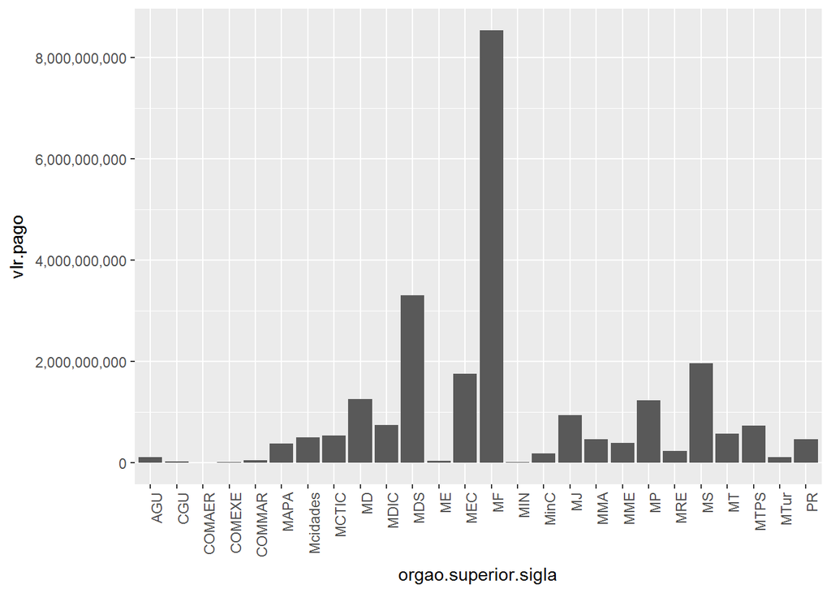

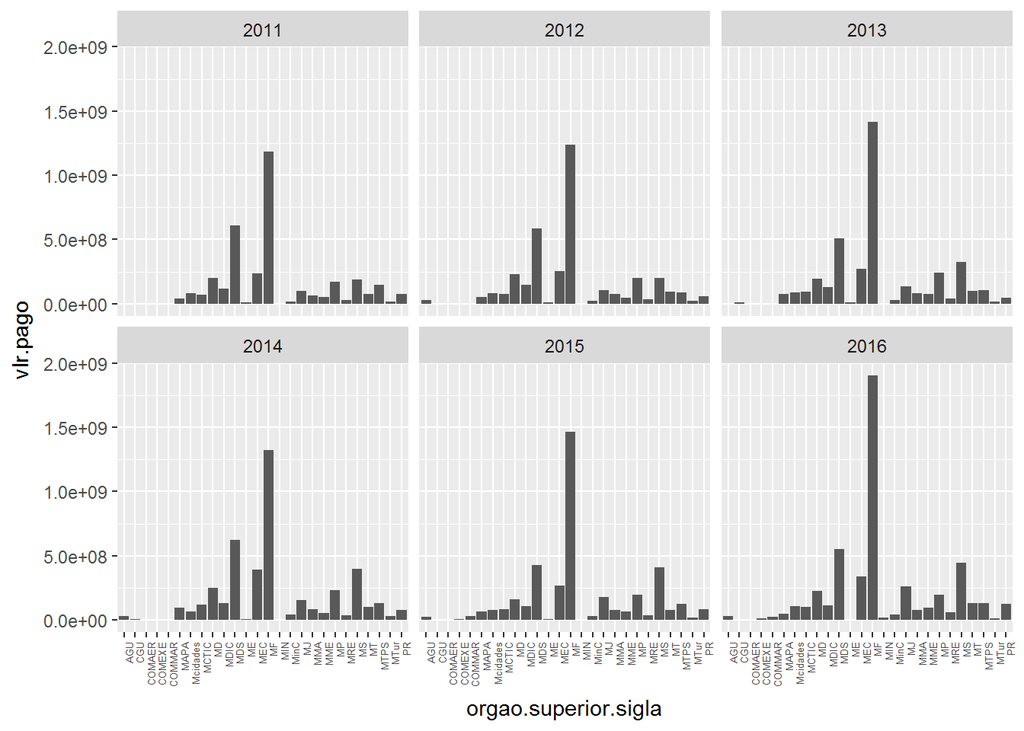

While on the previous session we discovered that MEC and MD were the departments with higher contracts count, when plotted by value, the Department of Treasury (MF) and Ministry of Social Development are the ones that most spent in these years.

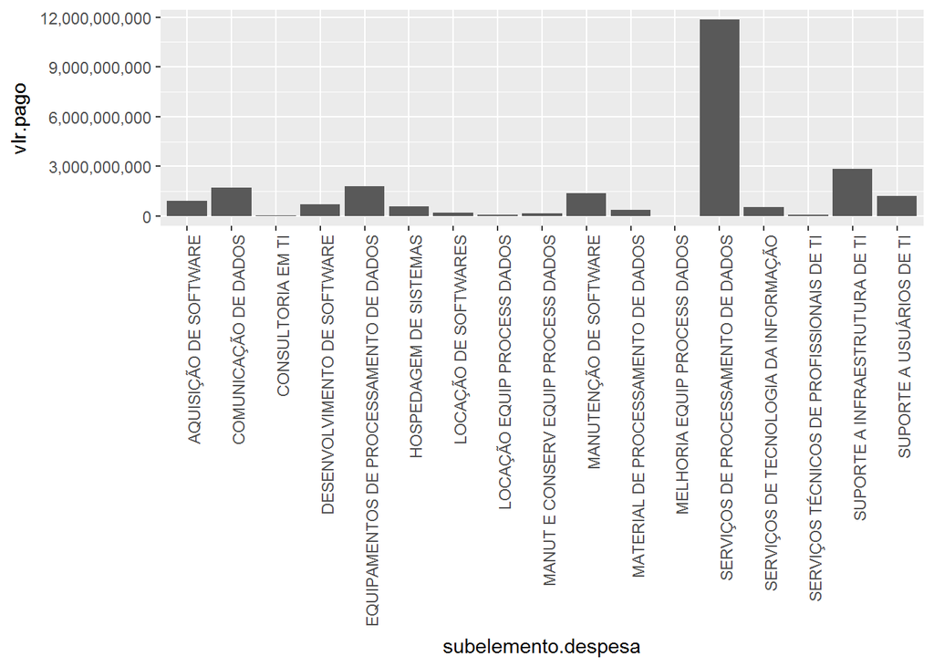

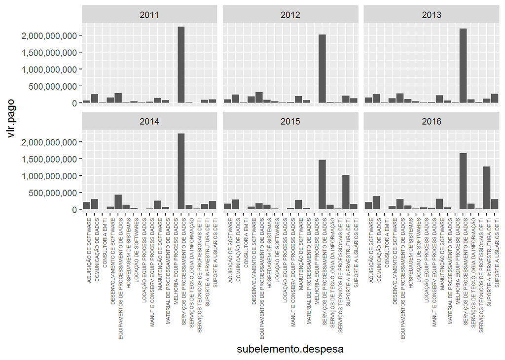

By the item contracted, between the years 2011-2014, the higher spent was “services for data processing”, but on the years 2015 and 2016 it seems that this item started to share it’s budget with “support to IT infrastructure”. This could be due to investments on on-premises data centers or cloud IaaS.

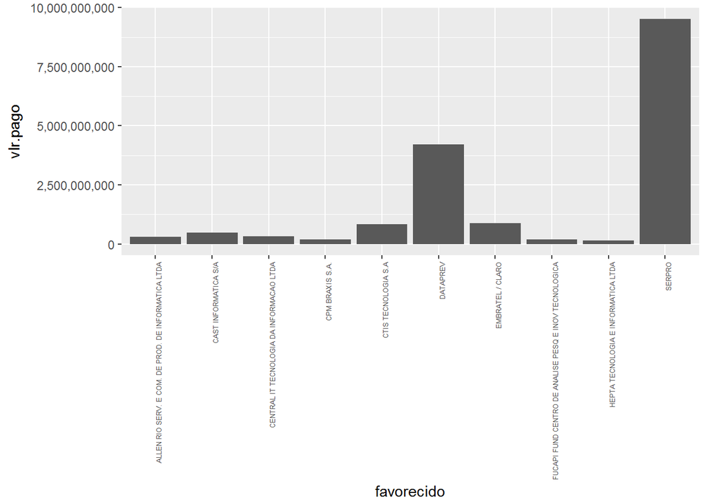

The two companies that invoiced the most were Serpro and Dataprev. These two companies are publics, founded to serve the federal government.

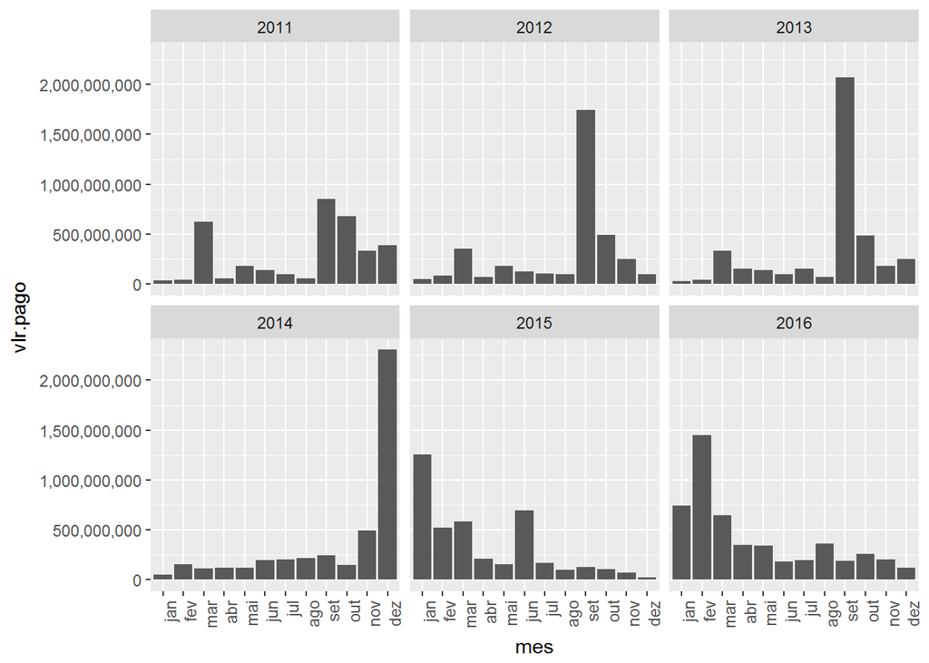

It doesn’t seems to have a pattern on month spent. The unusual is the month of December of the year 2014. 2014 was the election year and could explain this anomaly.

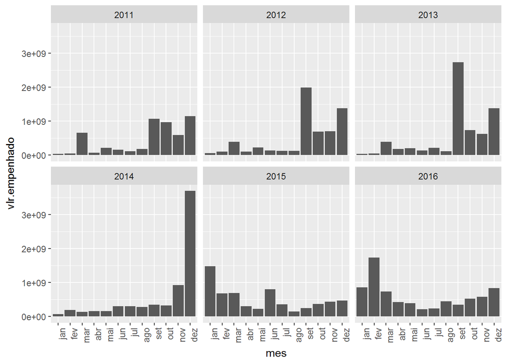

The reserved money to the contract plot is similar to the spent money plot. Which indicates that the dynamic of separating the money to the contract and actually paying it should occur within 1 month.

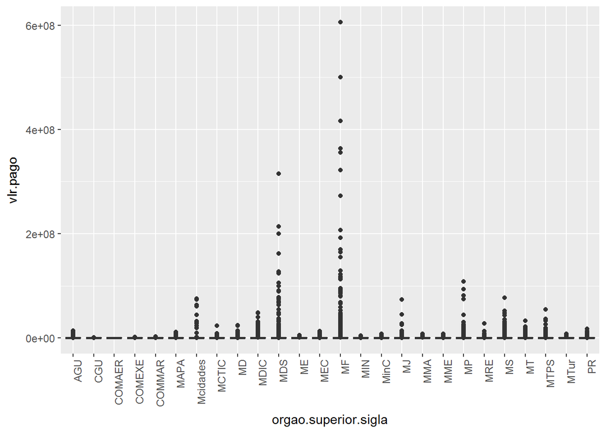

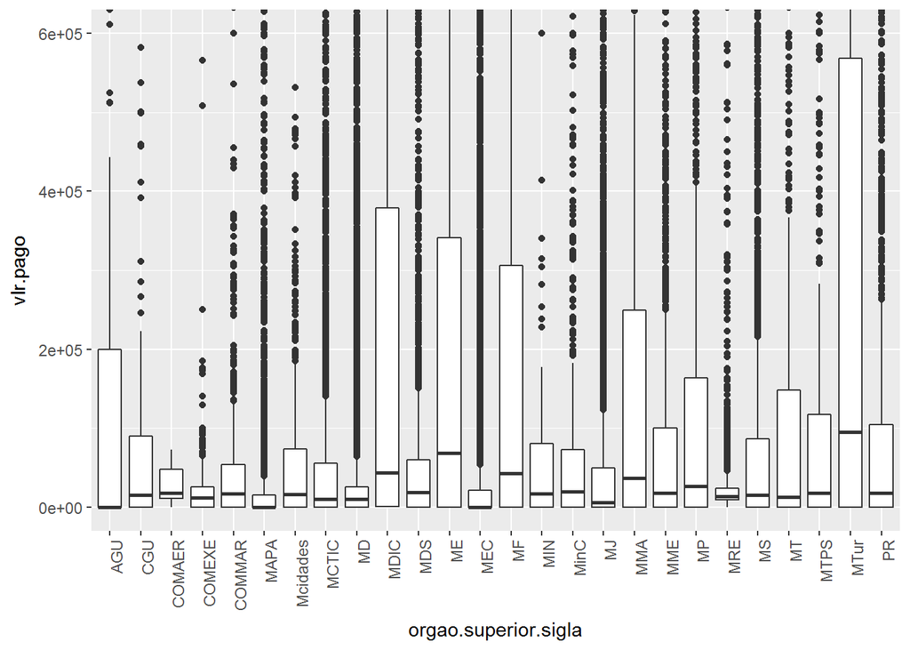

```
## # A tibble: 26 x 7
##    orgao.superior.sigla   min first_q median      mean    thir_q       max
##                   <chr> <dbl>   <dbl>  <dbl>     <dbl>     <dbl>     <dbl>
##  1                 MTur     0     0.0  95000  689156.8 568060.00   8283676
##  2                   ME     0     0.0  68927  321606.7 341666.50   4999792
##  3                 MDIC     0  1097.5  43512  871597.8 378622.00  48341730
##  4                   MF     0     0.0  43266 2983197.9 305874.75 605561275
##  5                  MMA     0     0.0  37320  303662.6 249439.50   8003921
##  6                   MP     0     0.0  26443  733236.2 163632.00 108016591
##  7                 MinC     0     0.0  19500  165694.1  73075.00   8255025
##  8                  MDS     0     0.0  19200 1028228.7  59999.75 315395505
##  9                 MTPS     0     0.0  18502  747281.3 117537.00  54998900
## 10                  MME     0     0.0  18483  191158.0  99968.00   7717114
## # ... with 16 more rows
```

This boxplot shows that there are a lot of outilers on contracts values. Ministry of External Relations - MRE is the one with lower interquartile range. Ministry of Turism - MTur has the highest median. AGU, MAPA and MEC has zero for median, indicating a high count on contracts without payments.

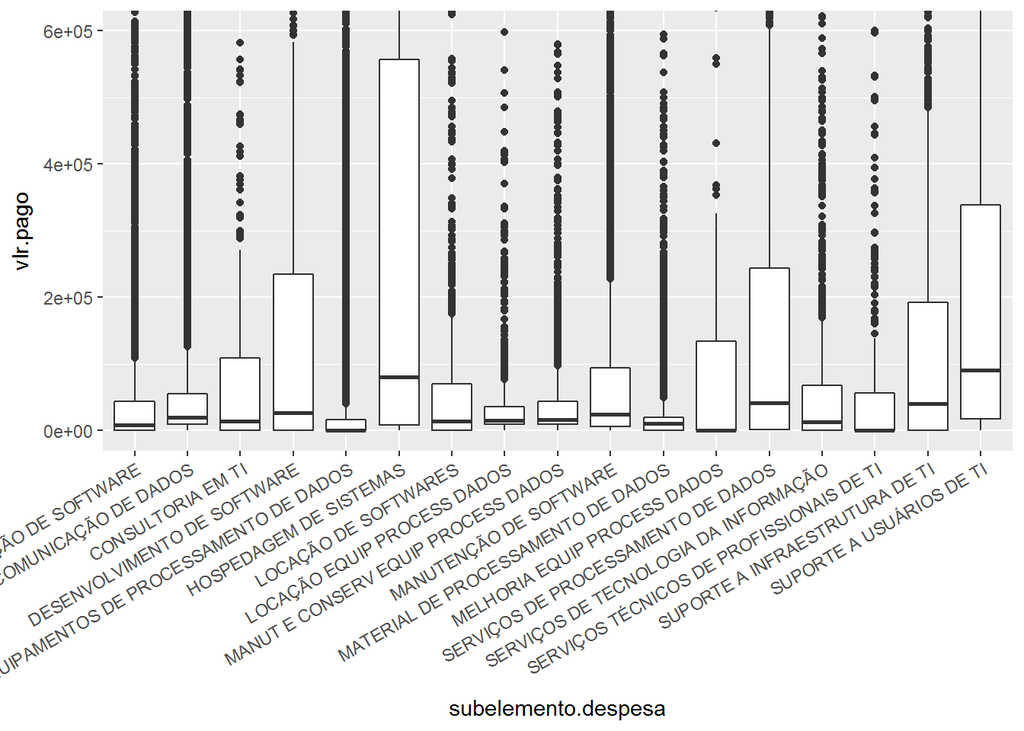

```
## # A tibble: 17 x 7
##                         subelemento.despesa   min  first_q median
##                                       <chr> <dbl>    <dbl>  <dbl>
##  1                 SUPORTE A USUÁRIOS DE TI     0 17211.50  90477
##  2                   HOSPEDAGEM DE SISTEMAS     0  8318.00  80083
##  3       SERVIÇOS DE PROCESSAMENTO DE DADOS     0  1312.25  41007
##  4           SUPORTE A INFRAESTRUTURA DE TI     0     0.00  39985
##  5              DESENVOLVIMENTO DE SOFTWARE     0     0.00  26601
##  6                   MANUTENÇÃO DE SOFTWARE     0  5732.00  24042
##  7                     COMUNICAÇÃO DE DADOS     0  8994.00  20206
##  8      MANUT E CONSERV EQUIP PROCESS DADOS     0  9293.00  16899
##  9              LOCAÇÃO EQUIP PROCESS DADOS     0  9078.00  14833
## 10                     LOCAÇÃO DE SOFTWARES     0     0.00  14387
## 11                        CONSULTORIA EM TI     0     0.00  14000
## 12     SERVIÇOS DE TECNOLOGIA DA INFORMAÇÃO     0     0.00  13250
## 13       MATERIAL DE PROCESSAMENTO DE DADOS     0     0.00  10530
## 14                    AQUISIÇÃO DE SOFTWARE     0     0.00   8290
## 15   EQUIPAMENTOS DE PROCESSAMENTO DE DADOS     0     0.00      0
## 16             MELHORIA EQUIP PROCESS DADOS     0     0.00      0
## 17 SERVIÇOS TÉCNICOS DE PROFISSIONAIS DE TI     0     0.00      0
## # ... with 3 more variables: mean <dbl>, thir_q <dbl>, max <dbl>
```

By item, “systems hosting” is the highest interquartile range, “IT users support” is the highest median and “IT staff technical services” the lowest.

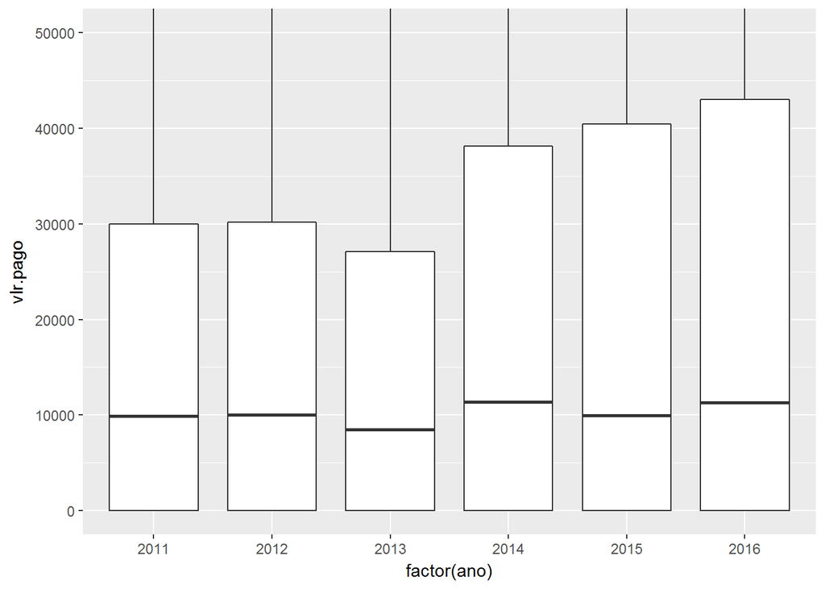

```
## # A tibble: 6 x 7
##     ano   min first_q median     mean  thir_q       max
##   <dbl> <dbl>   <dbl>  <dbl>    <dbl>   <dbl>     <dbl>
## 1  2014     0       0  11389 234926.7 38129.0 363103216
## 2  2016     0       0  11276 307055.0 42980.0 416493450
## 3  2012     0       0  10000 199426.0 30145.5 322031551
## 4  2015     0       0   9989 297098.4 40444.0 499731195
## 5  2011     0       0   9900 189418.0 30000.0 214034995
## 6  2013     0       0   8510 208403.4 27086.5 605561275
```

While the interquartile range grows across the years, the median does not seems to present a pattern. Lurking variables, like inflation, elections and corruption fight could be affecting this result.

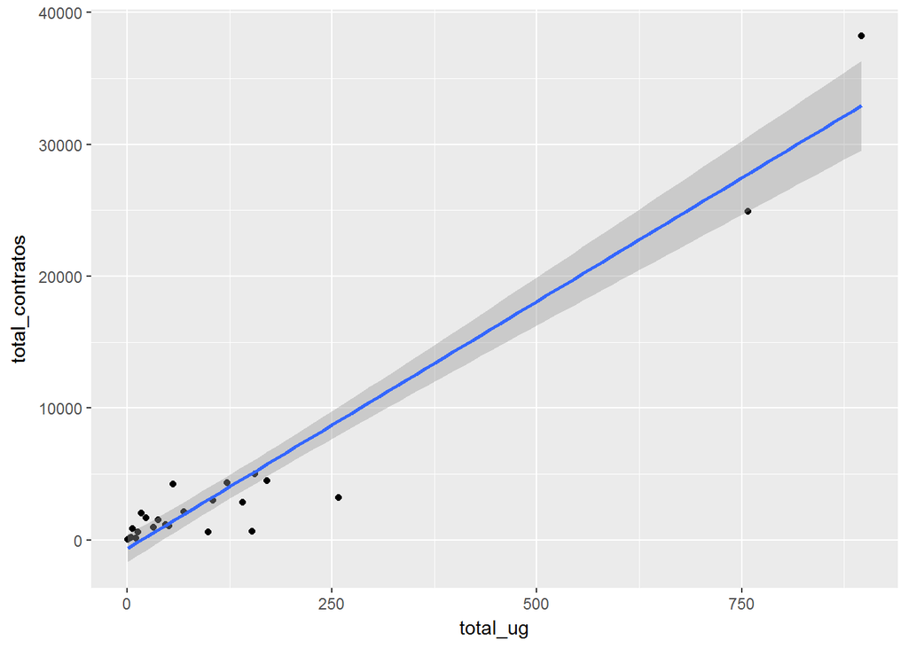

This scatter plot show the number of contracts by the number of management unit that a federal department has. It seems that higher unit counts leads to higher contract counts. This could be a room for improvement, the Departments could lead coletive purchases to reduced prices on high amounts.

```
##
##  Pearson's product-moment correlation
##
## data:  total_ug and total_contratos
## t = 18.277, df = 24, p-value = 1.369e-15
## alternative hypothesis: true correlation is not equal to 0
## 95 percent confidence interval:
##  0.9244182 0.9847986
## sample estimates:
##       cor
## 0.9659039
```

The correlation coefficient between number of unit managements and number of contracts is 0.97. This shows that they are highly correlated. It’s expected, as mentioned on the univariated plots section.

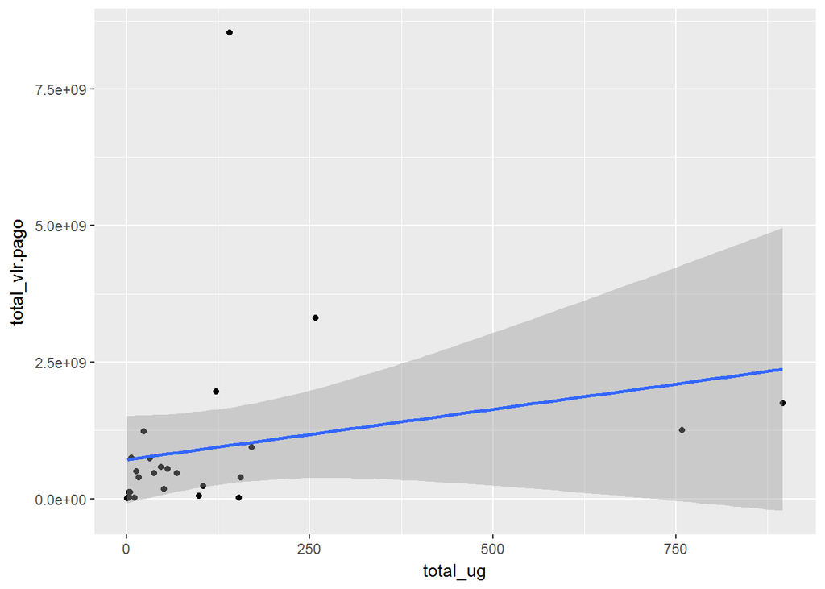

On the other hand, the values of the contracts does not seems to have a high correlation with the number of management units. Since the complexity and IT demand of different Departments are very specific, this seems correct. For example, while Ministry of Education, with several management units, should have high desktop demand, the Treasury should have high data processing demand.

```
##
##  Pearson's product-moment correlation
##
## data:  total_ug and total_vlr.pago
## t = 1.1778, df = 24, p-value = 0.2504
## alternative hypothesis: true correlation is not equal to 0
## 95 percent confidence interval:
##  -0.1688876  0.5695389
## sample estimates:
##       cor
## 0.2337565
```

The correlation coefficient of 0.23 confirms that these are not strong correlated.

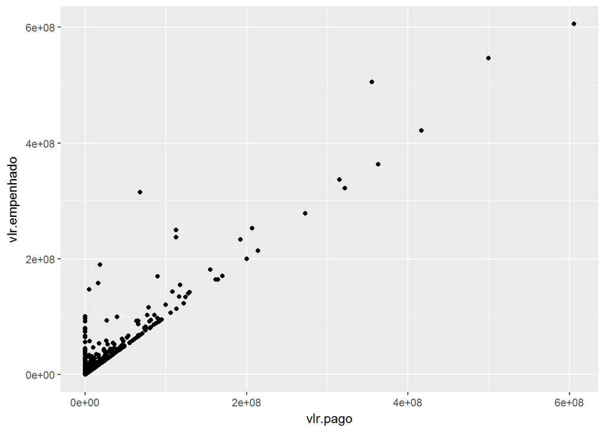

The expected plot was a straight line, meaning that the amount reserved and payed were the same. The points that move away from the line shows contracts that had more budget saved than payed.

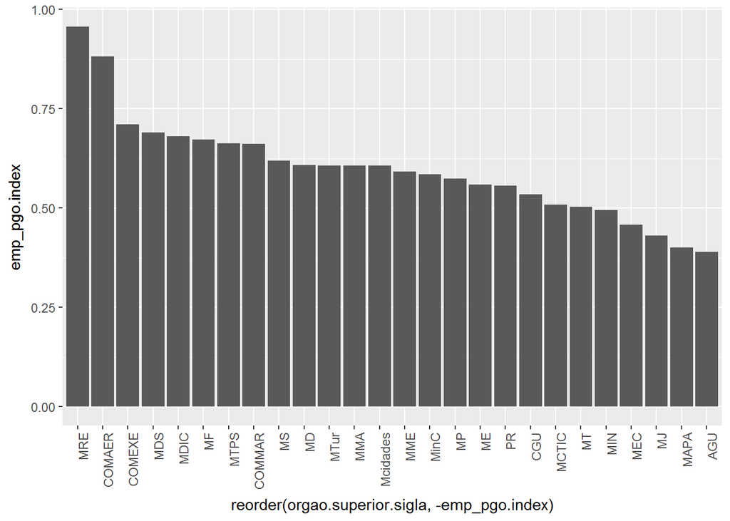

The emp_pgo.index variable shows the percentage of the reserved budget that was actually spent. Ministry of External Relations was the most precise planner and Federal Advocacy the worst.

# Bivariate Analysis

### Talk about some of the relationships you observed in this part of the investigation. How did the feature(s) of interest vary with other features in the dataset?

The number of contracts strongly correlates with the number of management units. Since every management unit has its own IT needs, it seems that the Departments with higher units will have more IT contracts. The correlation coefficient between number of contracts and number of management units is 0.97. This doesn’t mean that these Departments will spent more money. When compared the number of management units with contracts values, the correlation coefficient was only 0.23.

On the expenses by Department subject, the Treasury is the one with higher contracts values.

The other information observed on this section was the companies that most sold to the Government. The two main companies are Serpro and Dataprev. These companies are public and founded to serve mainly the Federal Government IT needs.

### Did you observe any interesting relationships between the other features (not the main feature(s) of interest)?

I noticed that after 2014 started a shift from the item “services for data processing” to the item “support to IT infrastructure” that could be explained by investments on on-premises data centers or cloud IaaS.

The distribution of the amount of money separated to the project and the amount of money payed to the company through the year are roughly the same. Which indicates that the dynamic of separating the money to the contract and actually paying it should occur within 1 month.

### What was the strongest relationship you found?

The number of contracts is positively and strongly correlated with the number of management units that a Department has. Also, the Treasury is the Department that most spent with IT.

# Multivariate Plots Section

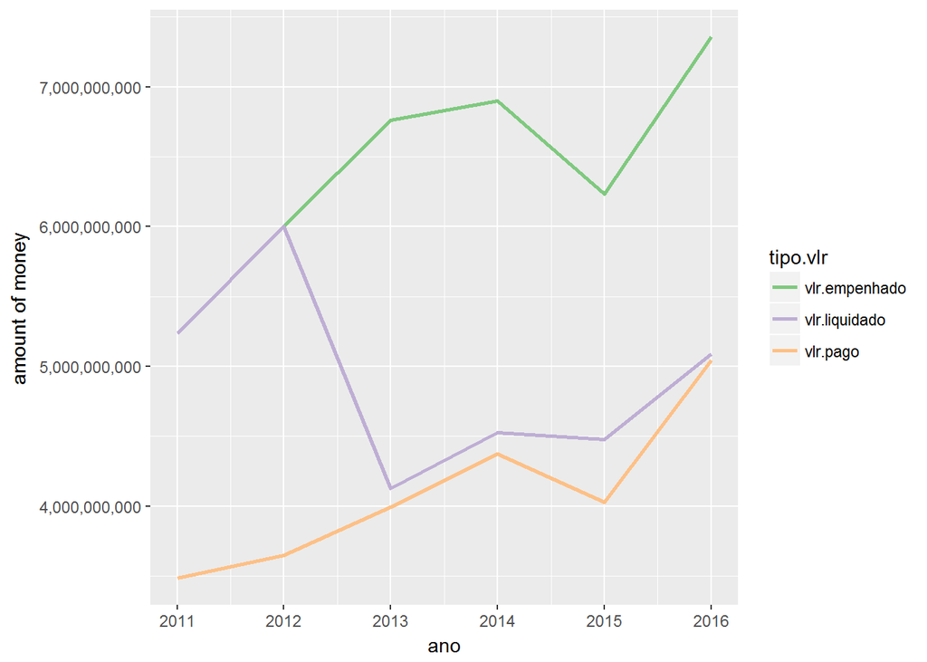

The distribution on years 2011 and 2012 is very odd. The gap of reserved and charged to payed is too high and the amount of reserved and charged been virtually the same doesn’t make much sense. For 2013 to 2016, the amount charged and payed are similar and the reserved value was very distant of the actually payed.

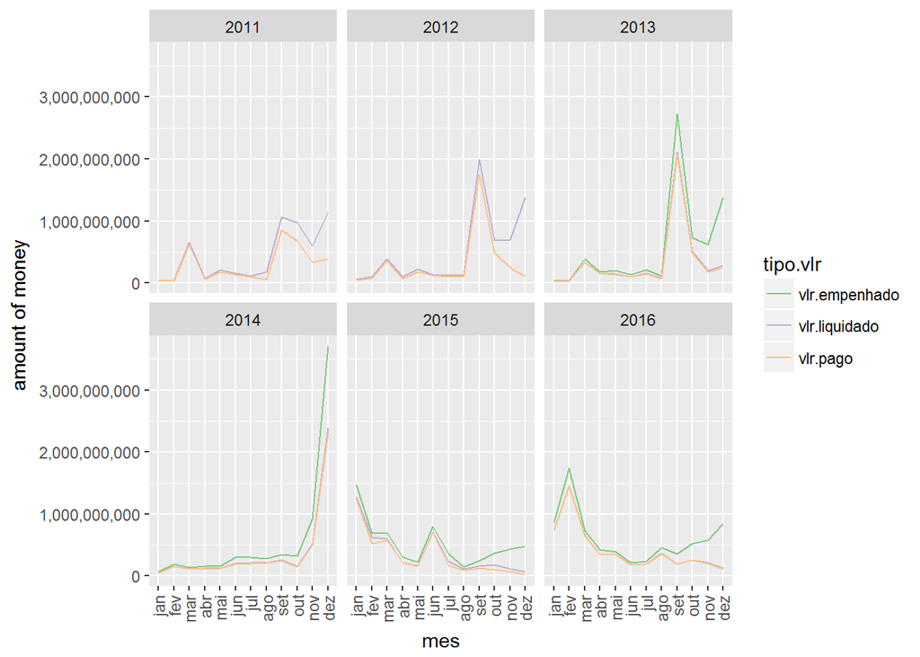